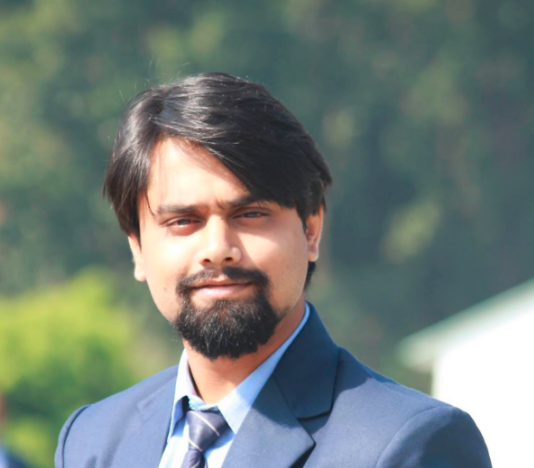

# Aman Singh

##### Bio

Highly skilled mid-senior professional, offering 7.5 years of experience in project, product service & delivery management, and process transformation & execution; Involved in development, monitoring & controlling projects concerning resource deployment, time overruns and quality compliance to ensure satisfactory execution of projects in VCM , Renewable energy and Discom segments.

##### Key work areas

Carbon Markets | Renewable Energy | Utility Domian | Power Market | Market Research | Product Management & Design | Digital Transformation & Strategy

Voluntary carbon market instrument trading and risk assessment, Power demand and renewable power generation forecasting, Power scheduling algorithms, Software product development and delivery of customized solutions for renewable energy IPPs and distribution companies, direct interaction with mid-level and senior executives in client organization.

##### Profile Summary

• Trading and risk assessment for instruments of voluntary carbon market.

• Headed a team of professional in designing Tech Solution for Forecasting & Scheduling of Renewable Energy (RE) Generators, Load Forecasting and Scheduling Products for DISCOMs and SLDCs, EPM Strategies.

• Involved in Architecture, Design, Development, Leading the team for further development & support for various Solutions related to Forecasting & Scheduling, CMS in RE Sector.

• Involved in planning and execution of Utility domain solutions for India’s largest State (population basis) and Capital of the country i.e UPPCL, BRPL, BYPL, PSPCL etc.

• Successfully developed product for RE Forecasting under DSM running over 20+ Plants to name few Acme, Azure, Softbank etc.

• Experienced in project management and operation activities including project scoping, estimation, planning, risk management, finalization of technical /functional specifications, resource administration

• Led a team i.e Technology, Data Science, Meteorological and Energy Analyst in developing various Products; provided direction, motivation & training to ensure optimum performance.

• Liaised with clients, internal teams (Software Developers, Data Scientists, Meteorologist, IT) for requirement and its development

• Direct client engagement and fabricating solution.

##### Experience

**Terra.do, London** | Fellow | May 2024 - Present

Role:

• Collaborating with a cohort of like-minded individuals to deepen the understanding of climate change complexities.

**Regent Climate Knowledge Solutions Private Limited (Subsidiary of ReNew Power Private Limited), Delhi/Gurgaon** | Senior Manager in Research and Strategy | April 2022 - January 2024

Role:

• Establishing the Carbon Trading Department in the company and focusing on risk analysis and market research within the domain.

• Managed carbon credit demand and supply aggregation within the company’s portfolio.

• Initiating connections with brokers and suppliers (generators) to facilitate the buying and selling of carbon credits.

• Managing the project screening process, before taking it on the company portfolio.

• Execute trading activities across multiple platforms, including broker channels and direct transactions with originators.

• Calculated Demand breakdown, Supply side aggregation, portfolio-level VaR , Mark to Market, Inventory Management, and PnL calculations.

• Computing value at risk (VaR) for both long and short positions, leveraging parametric and non-parametric methods.

• Generated daily and weekly carbon insight reports, featuring essential metrics and indicators in a concise and easily digestible format. Conducted comparative analysis with historical data and benchmarks for trend assessment.

• Delivered weekly portfolio reports to company stakeholders to ensure transparency and effective communication of trading activities.

• Consulted with the United Kingdom electricity retail max team to shape and refine ideas on procurement, financial management, and risk assessment for the implementation of the Champion Energy pilot project.

Highlights:

• Instrumental in establishing the Carbon Trading department, now managing a $3 million portfolio within the organization. Consequently, the trading/procurement team achieved a consistently positive PnL for the company portfolio.

**Regent Climate Knowledge Solutions Private Limited (Subsidiary of ReNew Power Private Limited), Delhi/Gurgaon** | Delivery Manager | August 2020 - March 2022

Role:

• Lead Product Manager for the Andaman Energy Management Center software in collaboration with Power Grid Corporation of India (PGCIL) and General Electric (GE), overseeing its development and strategic growth within the electricity domain.

• Directed the management and development of the Telangana Renewable Energy Management Center software in collaboration with Power Grid Corporation of India (PGCIL) and Asea Brown Boveri (ABB), ensuring its alignment with industry needs and standards.

• Drove the management and development of the forecasting software for Jammu and Kashmir in partnership with J&K SLDC and General Electric (GE), enhancing forecasting accuracy within the electricity sector.

• Provided consultation and development leadership for an in-house product, the Virtual Trading Platform for renewable generators (Concept Phase) facilitating efficient energy trading in the renewable energy market.

Highlights:

• Successfully achieved the Site Acceptance Test (SAT) for the Andaman demand and renewable generation Forecasting & Scheduling software, ensuring its operational readiness and reliability.

• Attained a significant milestone by accomplishing the Factory Acceptance Test (FAT) for the Telangana Renewable Energy Management Center (REMC) software, demonstrating its robustness and adherence to industry standards.

• Demonstrated expertise by accomplishing the Factory Acceptance Test (FAT) for the Jammu & Kashmir state demand forecasting software, ensuring its accuracy and reliability in forecasting electricity demand within the region.

**Regent Climate Knowledge Solutions Private Limited, Pune/Delhi** | Utilities Delivery Head | November 2018 - August 2020

Role:

• Developing products & solution for F&S, EPM for the Power sector (DISCOM).

• Interfacing between client & company; assessing client & market needs and preparing products and solutions

• Managing the business relationship with Discom/SLDC

• Providing technical solutions for Load Forecasting and scheduling products for DISCOMs and SLDC

• Coordinating with client & internal team (Data Scientists, Meteorologist, IT Team) for driving improvement in the forecasting module

• Working with energy and power analyst to build the logic for scheduling of Discom/SLDC

• Implemented a Loss Reduction Activity Impact project at a Delhi‑based Distribution Company. The primary focus was on the gain in energy and further observing the financial gain

Highlights:

• Overall 30,000 MW of load forecasting contract was awarded, which included Uttar Pradesh, BRPL, BYPL and TPDDL

**Regent Climate Knowledge Solutions Private Limited, Pune/Delhi** | Product Development Analyst | November 2017 - October 2018

Role:

• Second in line to a product manager; developing products & solution for F&S, Asset Management Renewable Energy Sector

• Interfacing between client, product manager & company internal team; assessing client & market needs and preparing products and solutions

• Guiding Tech Team and Data Scientists for developing product

• Managing the business relationship with the client, RE generators/SLDCs

• Analyzing weather models and evaluating real-time Solar Data and improving upon the forecasting accuracy; setting up and managing Operation Centre 7*52

• Coordinating with clients, product manager & internal team (Data Scientists, Meteorologists, and IT Team) for driving improvement in the forecasting module

Highlights:

• Directed a team to develop Load and Scheduling Product & RE Forecasting and Scheduling Product

• Steered efforts made for the company to get Series A Funding and gave the highest rating to the product

**Regent Climate Knowledge Solutions Private Limited, Delhi** | Market Analyst | September 2016 - October 2017

Role:

• Worked on the development of data information portals targeted at the Indian power market called “India Power Trading”

• Worked with a team of Energy Analysts and Software Analysts to develop India’s only analytical publication on the trends of the short‑term power market (Morning Megawatt)

• Worked for the development of India’s first and only publication that tracked daily renewable energy generation at the State and National level (Green Megawatt)

• Helped Data Scientists with the development of day‑ahead market price forecast for IEX from the domain end.

Highlights:

• Managed to have a good paid client base for the daily reports and the web portal.

##### Education

**University of Petroleum & Energy Studies** | Dehradun, India

M.Tech in Energy System | 2014 - 2016

**Uttar Pradesh Technical University** | Mathura, India

B.Tech in Mechanical Engineering | 2007 - 2011